# Zillow Exploratory Data Analysis - Geostatistical & Spatial Analysis

As the final capstone project for UCLA Statistics’ Undergraduate Program, we were tasked to work with clients in performing an exploratory data analysis and performance of machine learning techniques on a dataset of their choice.

Our client asked us to perform and EDA on the selling of properties on Zillow. My personal contribution to this project was performing a spatial analysis, and visualizing how the ‘Days Sold’ measurement varied in its geographical location.

The analysis was performed in R, with the libraries dplyr for data cleaning and data manipulation. Leaflet was used for geographical visualization. geoR was used to access geostatistical tools such as variograms, alongside other data visualization tools.

We first begin with loading the data and preparing it for use in R.

```r
library("readxl")
data <- read_xlsx("zillow.xlsx", col_names = FALSE, skip = 1)
colnames(data) <- data[1,]
head(data, n = 100)
```

```
## # A tibble: 100 × 44
##    `Street Address`           City      County State Country Zipcode `Ziilow Id`
##    <chr>                      <chr>     <chr>  <chr> <chr>   <chr>   <chr>
##  1 Street Address             City      County State Country Zipcode Ziilow Id
##  2 829 W 66th St              Los Ange… Los A… CA    USA     90044   20934009
##  3 9673 Via Torino #154       Burbank   Los A… CA    USA     91504   20033668
##  4 9673 Via Torino            Burbank   Los A… CA    USA     91504   2088531295
##  5 13621 Simshaw Ave          Sylmar    Los A… CA    USA     91342   20102436
##  6 4600 Don Lorenzo Dr APT 30 Los Ange… Los A… CA    USA     90008   61361676
##  7 13445 Astoria St           Sylmar    Los A… CA    USA     91342   20068579
##  8 7555 Claire Ave            Reseda    Los A… CA    USA     91335   19905288
##  9 8043 Norwich Ave           Panorama… Los A… CA    USA     91402   19955361
## 10 5016 Bakman Ave UNIT 102   North Ho… Los A… CA    USA     91601   95529292
## # … with 90 more rows, and 37 more variables: `Property Url` <chr>,
## #   Bedrooms <chr>, Bathrooms <chr>, `Property Status` <chr>,
## #   `Property Type` <chr>, `Living Area` <chr>, Zestimate <chr>,
## #   `Living Area Unit` <chr>, `Has Cooling` <chr>, Cooling <chr>,
## #   `Has Fireplace` <chr>, Fireplaces <chr>, `Has Heating` <chr>,
## #   Heating <chr>, `Has Parking` <chr>, `Parking Capacity` <chr>,
## #   Parking <chr>, Price <chr>, Currency <chr>, `Year Built` <chr>, …
```

Here, we performed some data cleaning and pooled the entries with the status ‘RECENTLY SOLD’ and ‘SOLD’

```r
library(dplyr)
sold <- rbind(
data %>% filter(`Property Status` == "RECENTLY_SOLD"),
data %>% filter(`Property Status` == "SOLD")
)

sold_numerical <- sold[,c("Price", "Year Built", "Days On Zillow")]

sold_numerical <- sold_numerical %>% filter(is.na(`Year Built`) == FALSE)

z <- cbind(
  as.numeric(sold_numerical$Price),
  as.numeric(sold_numerical$`Year Built`),
  as.numeric(sold_numerical$`Days on Zillow`)
)
```

As a way to visualize the data, I used the Leaflet mapping library. Each marker, when clicked, displays the days sold.

```r
library(leaflet)
data <- rbind(
data %>% filter(`Property Status` == "RECENTLY_SOLD"),
data %>% filter(`Property Status` == "SOLD")
)

latlng <- cbind(as.numeric(data$Latitude), as.numeric(data$Longitude))
latlng[2,]
```

```
## [1]   34.21074 -118.34243
```

```r
m <- leaflet()
m <- addTiles(m)

for(i in seq_len(100)) {
  m <- addMarkers(m, lng=latlng[i,2], lat=latlng[i,1], popup=data$`Days On Zillow`[i])
}

m
```

[interactive chart not shown]

In this step, I have prepared the data for use in the geoR library. I have extracted the latitude and longitude measurements from the dataset, and binded the columns together. The final column in the set is the ‘Days Sold’ measurement. This data table can be imagined with the latitude and longitude representing the input functions and the ‘Days Sold’ acting as an output measurement.

```r
library(geoR)
jdc <- jitterDupCoords(latlng, max = 0.01)
xyz <- head(data.frame(jdc, as.numeric(data$`Days On Zillow`)), n = 30000)
#xyz <- head(data.frame(jdc, log(as.numeric(data$Price))), n = 30000)
xyz <- xyz[-1,]
head(xyz)
```

```
##         X1        X2 as.numeric.data..Days.On.Zillow..
## 2 34.20709 -118.3365                                 3
## 3 34.31926 -118.4133                                 4
## 4 33.99519 -118.3616                                 4
## 5 34.32317 -118.4261                                 5
## 6 34.20814 -118.5505                                 5
## 7 34.21728 -118.4612                                 5
```

Here, I use the geoR as.geodata() function to provide a spatial analysis. We can see how the data is varied across the latitude and longitude axes. The top left graph provides a geographical shape which matches the above leaflet map. The bottom right graph provides a density graph which indicates an empirical uniform distribution.

```r
rands <- xyz[sample(nrow(xyz), 2000),]
b <- as.geodata(rands)
```

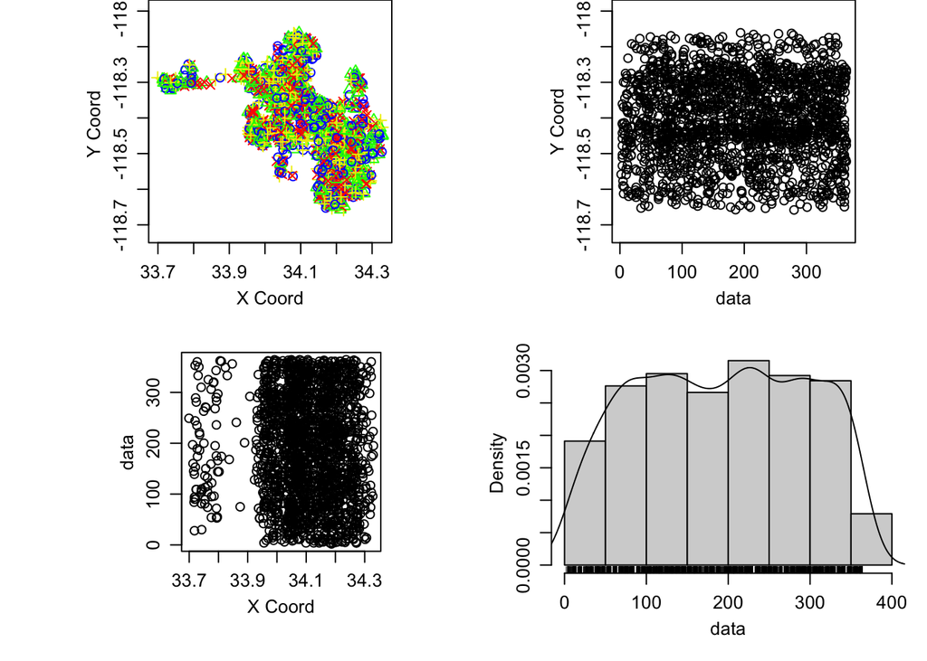

```r
plot(b)
```

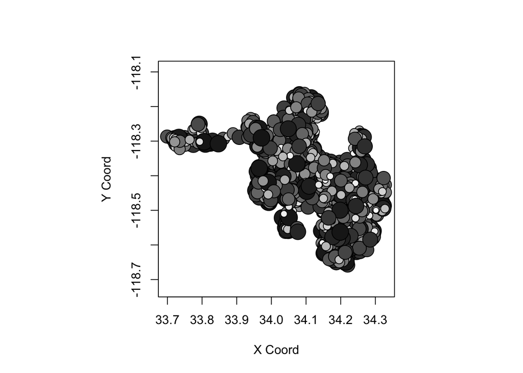

```r
points(b, cex.min=1, cex.max=3, col="gray")
```

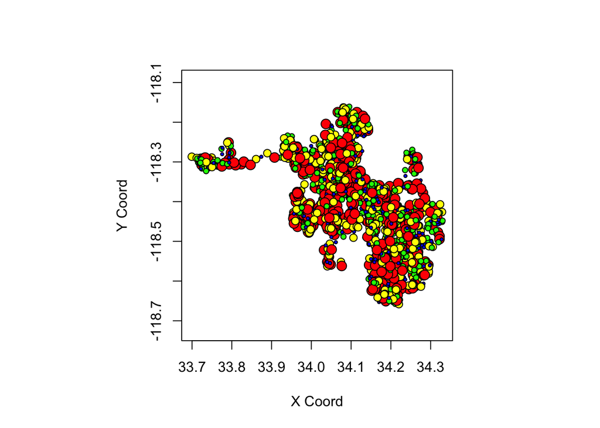

```r
points.geodata(b, pt.divide="quartile")
```

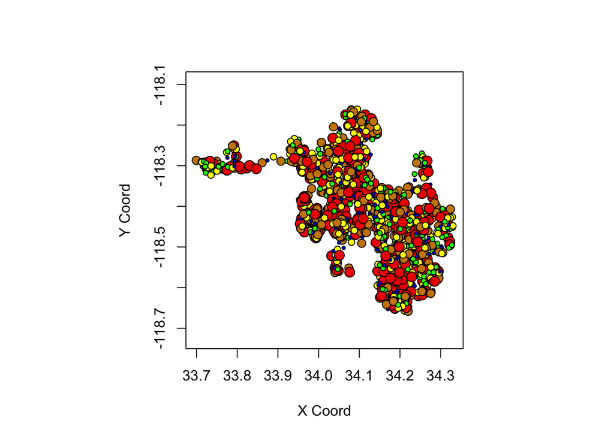

```r
points.geodata(b, pt.divide="quintile")
```

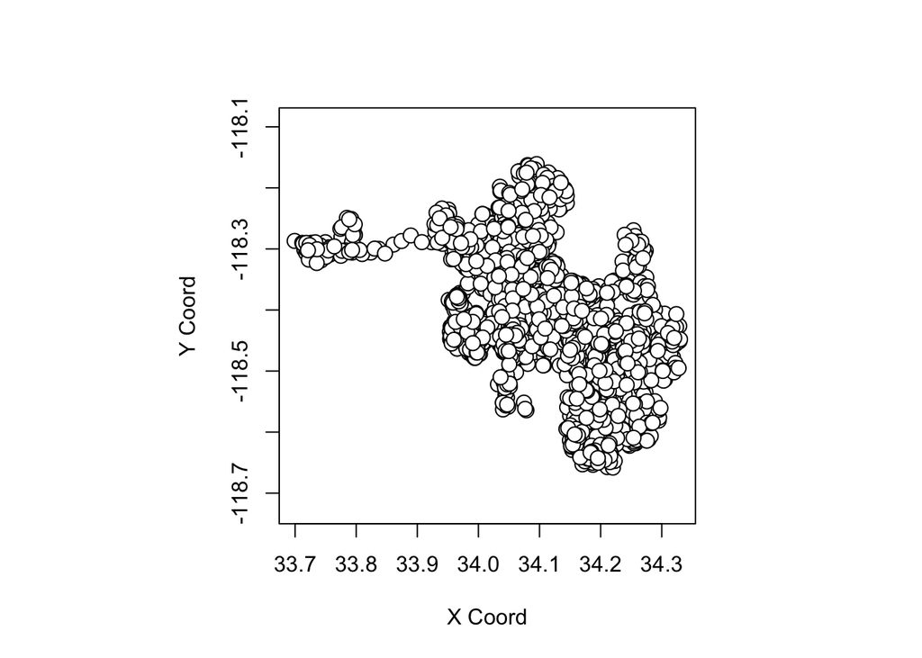

```r
points.geodata(b, pt.divide="equal")
```

Here, I decided to perform a variogram. A variogram measures the average variance per distance. Surprisingly, the variance is nearly constant across the average distances which may indicate there is no obvious change in the ‘Days Sold’ as we increase geographical distance.

```r
variogram1 <- variog(b, max.dist=900)
```

```
## variog: computing omnidirectional variogram
```

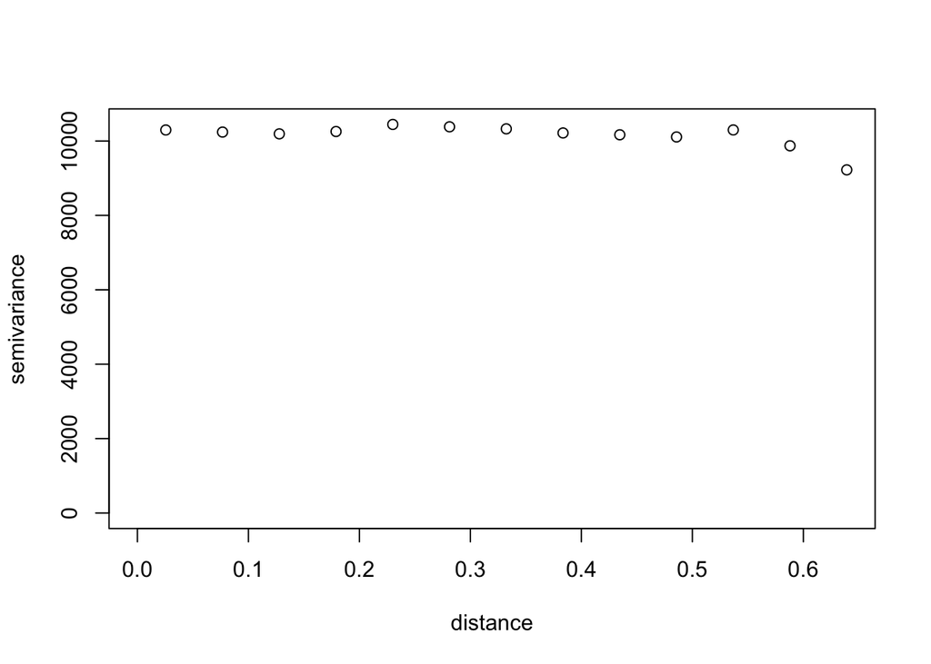

```r
plot(variogram1)
```

```r
variogram2 <- variog(b, dir=pi, max.dist=900, tol=pi/6)
```

```
## variog: computing variogram for direction = 180 degrees (3.142 radians)
##         tolerance angle = 30 degrees (0.524 radians)
```

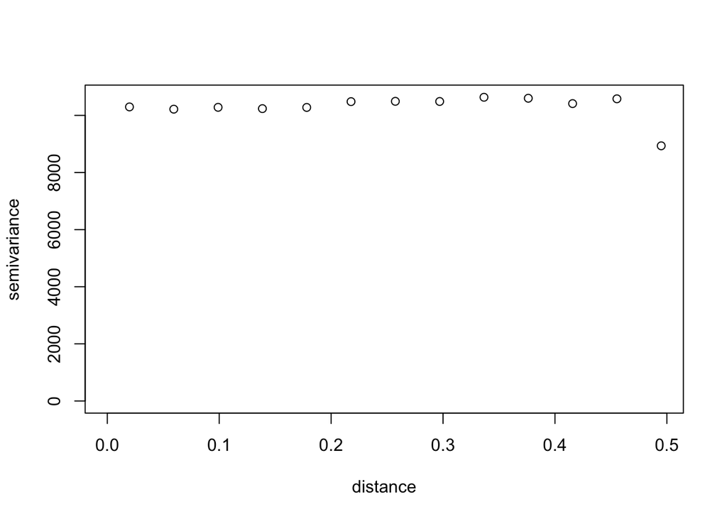

```r
plot(variogram2)
```